# Exploratory Data Analysis On White Wine Dataset

The project is aimed at looking and finding deep insights of the white wine dataset. The report also aims in bringing us to a conclusion so as to what are the factors that affect the quality of wine.

# Data description

The data is in csv format.In computing, a comma-separated values (CSV) file stores tabular data (numbers and text) in plain text. Each line of the file is a data record. Each record consists of one or more fields, separated by commas.

All wines are produced in a particular area of Portugal. Data are collected on 12 different properties of the wines one of which is Quality, based on sensory data, and the rest are on chemical properties of the wines including density, acidity, alcohol content etc. All chemical properties of wines are continuous variables. Quality is an ordinal variable with possible ranking from 1 (worst) to 10 (best). Each variety of wine is tasted by three independent tasters and the final rank assigned is the median rank given by the tasters.

# Attribute Information:

For more information, read [Cortez et al., 2009]. Input variables (based on physicochemical tests):

```python
from IPython.display import HTML

HTML('''<script>
code_show=true;
function code_toggle() {
 if (code_show){
 $('div.input').hide();
 } else {
 $('div.input').show();
 }
 code_show = !code_show
}
$( document ).ready(code_toggle);
</script>
<form action="javascript:code_toggle()"><input type="submit" value="Click here to toggle on/off the raw code."></form>''')
```

[figure not shown]

#### Importing libraries which we need to plot

```python
import pandas as pd
import matplotlib.pyplot as plt
import seaborn as sns
%matplotlib inline
```

#### Read the Data set of winequlity-white which is available in csv

```python
df=pd.read_csv("C:\Users\Dell\Downloads\winequality-white.csv")
```

#### To view the dataframe of imported data we use head() which gives five rows to view,by default.

```python
df.head()
```

|  | fixed acidity | volatile acidity | citric acid | residual sugar | chlorides | free sulfur dioxide | total sulfur dioxide | density | pH | sulphates | alcohol | quality |
| --- | --- | --- | --- | --- | --- | --- | --- | --- | --- | --- | --- | --- |
| 0 | 7.0 | 0.27 | 0.36 | 20.7 | 0.045 | 45.0 | 170.0 | 1.0010 | 3.00 | 0.45 | 8.8 | 6 |
| 1 | 6.3 | 0.30 | 0.34 | 1.6 | 0.049 | 14.0 | 132.0 | 0.9940 | 3.30 | 0.49 | 9.5 | 6 |
| 2 | 8.1 | 0.28 | 0.40 | 6.9 | 0.050 | 30.0 | 97.0 | 0.9951 | 3.26 | 0.44 | 10.1 | 6 |
| 3 | 7.2 | 0.23 | 0.32 | 8.5 | 0.058 | 47.0 | 186.0 | 0.9956 | 3.19 | 0.40 | 9.9 | 6 |
| 4 | 7.2 | 0.23 | 0.32 | 8.5 | 0.058 | 47.0 | 186.0 | 0.9956 | 3.19 | 0.40 | 9.9 | 6 |

You can use the Dataframe .info() method to check out data types and null values and more.

```python
df.info()
```

```
<class 'pandas.core.frame.DataFrame'>
RangeIndex: 4898 entries, 0 to 4897
Data columns (total 12 columns):
fixed acidity           4898 non-null float64
volatile acidity        4898 non-null float64
citric acid             4898 non-null float64
residual sugar          4898 non-null float64
chlorides               4898 non-null float64
free sulfur dioxide     4898 non-null float64
total sulfur dioxide    4898 non-null float64
density                 4898 non-null float64
pH                      4898 non-null float64
sulphates               4898 non-null float64
alcohol                 4898 non-null float64
quality                 4898 non-null int64
dtypes: float64(11), int64(1)
memory usage: 459.3 KB
```

You can also check shape of DataFrame by using .shape

```python
df.shape
```

```
(4898, 12)
```

You can also check size od DataFrame by using .size

```python
df.size
```

```
58776
```

To get the described view of dataframe of dataset we use described function,which gives us described form of all columns,as we can see like count,mean,max,min and many more.Also, use the DataFrame .describe() method to check out summary statistics of numeric columns

```python
df.describe(include='all')
```

|  | fixed acidity | volatile acidity | citric acid | residual sugar | chlorides | free sulfur dioxide | total sulfur dioxide | density | pH | sulphates | alcohol | quality |
| --- | --- | --- | --- | --- | --- | --- | --- | --- | --- | --- | --- | --- |
| count | 4898.000000 | 4898.000000 | 4898.000000 | 4898.000000 | 4898.000000 | 4898.000000 | 4898.000000 | 4898.000000 | 4898.000000 | 4898.000000 | 4898.000000 | 4898.000000 |
| mean | 6.854788 | 0.278241 | 0.334192 | 6.391415 | 0.045772 | 35.308085 | 138.360657 | 0.994027 | 3.188267 | 0.489847 | 10.514267 | 5.877909 |
| std | 0.843868 | 0.100795 | 0.121020 | 5.072058 | 0.021848 | 17.007137 | 42.498065 | 0.002991 | 0.151001 | 0.114126 | 1.230621 | 0.885639 |
| min | 3.800000 | 0.080000 | 0.000000 | 0.600000 | 0.009000 | 2.000000 | 9.000000 | 0.987110 | 2.720000 | 0.220000 | 8.000000 | 3.000000 |
| 25% | 6.300000 | 0.210000 | 0.270000 | 1.700000 | 0.036000 | 23.000000 | 108.000000 | 0.991723 | 3.090000 | 0.410000 | 9.500000 | 5.000000 |
| 50% | 6.800000 | 0.260000 | 0.320000 | 5.200000 | 0.043000 | 34.000000 | 134.000000 | 0.993740 | 3.180000 | 0.470000 | 10.400000 | 6.000000 |
| 75% | 7.300000 | 0.320000 | 0.390000 | 9.900000 | 0.050000 | 46.000000 | 167.000000 | 0.996100 | 3.280000 | 0.550000 | 11.400000 | 6.000000 |
| max | 14.200000 | 1.100000 | 1.660000 | 65.800000 | 0.346000 | 289.000000 | 440.000000 | 1.038980 | 3.820000 | 1.080000 | 14.200000 | 9.000000 |

To see is there any null value present in dataset we use isnull() with sum up operation . As we see there is no null value present in dataset,If null vlaue present inthe dataset then we have to remove that null values

```python
df.isnull().sum()
```

```
fixed acidity           0
volatile acidity        0
citric acid             0
residual sugar          0
chlorides               0
free sulfur dioxide     0
total sulfur dioxide    0
density                 0
pH                      0
sulphates               0
alcohol                 0
quality                 0
dtype: int64
```

# Univariate Analysis

Uni means one.Univariate means one variable analysis.Univariate analysis explores each variable in a data set. Variables could be either categorical or numerical.There are different statistical and visualization techniques of investigation for each type of variable.The key pointers to the univariate analysis is to find out outliers present in data.

### Quality Countplot

Here the Quality countplot.We can notice the following trend.

1. The Quality Rating 5 and 6 is high in number.
2. We can see few wines which are rated as 7 and 8,but both are nowhere near the 5 and 6.

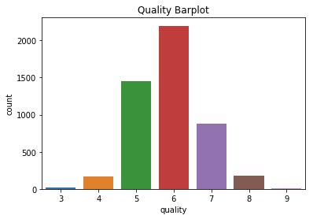

```python
sns.countplot(x='quality',data=df)
plt.title("Quality Barplot")
plt.show()
```

### Alcohol Countplot

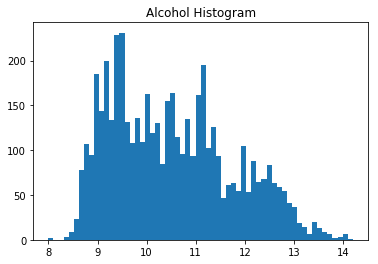

```python
plt.hist(x='alcohol',data=df,bins=60)
plt.title("Alcohol Histogram")
plt.show()
sns.despine()
```

### Sulphates Countplot

we plot the Distributed plot for sulphates, By plotting we get the keys points related to sulphates.

1. We can a small skewness for a particular column.
2. As we can see the in more wines bottles sulphates content are present between 0.4 to 0.57.
3. For most important outliers we can see boxplot for the same from which we can easily determined,that more number of outliers are present.

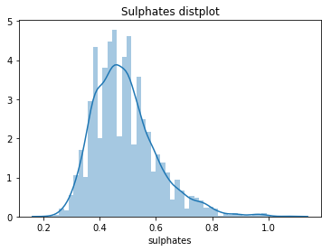

```python
sns.distplot(df['sulphates'])
plt.title("Sulphates distplot")
plt.show()
```

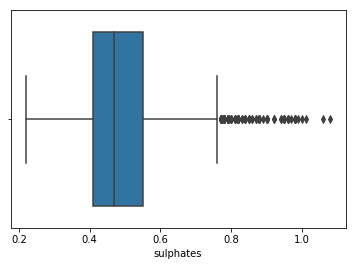

```python
sns.boxplot(x='sulphates',data=df)
```

### pH countplot

By plotting boxplot for pH column we can observe the following key points.

1. As there is huge amount pf outliers present.
2. we can see outliers before the interval start is less as compared to outliers after the interval ends.

By plotting histogram for the same pH column we see.

1. There is normal distribution that is no skewness present.
2. we can observe bell shaped curve.
3. It is continous.

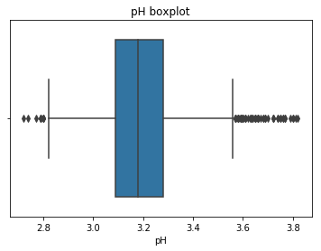

```python
sns.boxplot(x='pH',data=df)
plt.title("pH boxplot")
plt.show()
sns.despine()
```

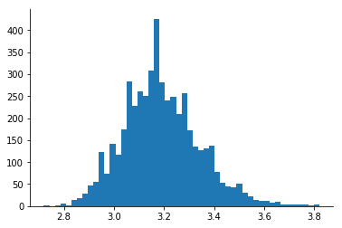

```python
plt.hist(x='pH',data=df,bins=50)
sns.despine()
```

### Density Countplot

So we plotted the density distributed plots to catch the outliers.Below are the key points.

1. we can see skewness of density column .
2. We observe few outliers.
3. Highest density lies between 0.99% to 1.00%.

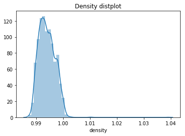

```python
sns.distplot(df['density'])
plt.title("Density distplot")
plt.show()
```

### Total Sulphur dioxide countplot

1. we observe normal distribution of particular column.
2. very few outliers.
3. most of the wines bottles contains sulphur di-oxide content between 100% to 160%.

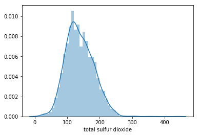

```python
sns.distplot(df['total sulfur dioxide'])
```

### free sulphur dioxide countplot

1. we can observe skewness of particular column.
2. we also observe outliers from the distributed plot.

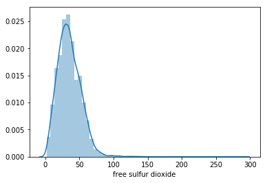

```python
sns.distplot(df['free sulfur dioxide'])
```

### Chloride - count plot

from the chloride count plot we can observe following trend.

1. we can observe very large amount of outliers from boxplot of chloride.
2. They are continous in nature.
3. We also observe skewness .
4. chloride value are less for most of the wine.
5. Most of the wine bottles have chloride level of less than 0.1g/dm^3.

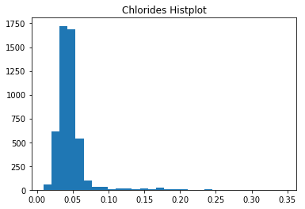

```python
plt.hist(x='chlorides',data=df,bins=30)
plt.title("Chlorides Histplot")
plt.show()
sns.despine()
```

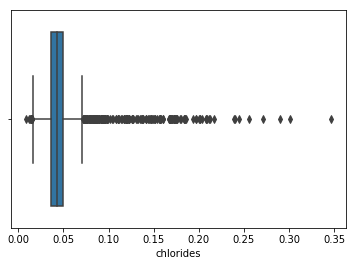

```python
sns.boxplot(df['chlorides'])
```

### Residual sugar - countplot

from boxplot we can observe:

1. There are few outliers present in this column.

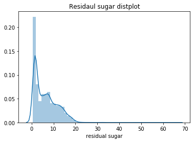

```python
sns.distplot(df['residual sugar'])
plt.title("Residaul sugar distplot")
plt.show()
```

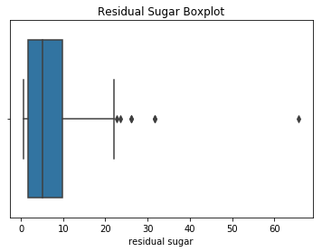

```python
sns.boxplot(df['residual sugar'])
plt.title("Residual Sugar Boxplot")
plt.show()
```

### Citric acid - countplot

from displot we can observe trends

1. we can observe little skewness in this column.
2. These are continous.
3. In most of wines bottles we can observe citric acid of amount between 0.25% to 0.40%.

from boxplot we can observe trends

1. we can observe large amount of outliers.

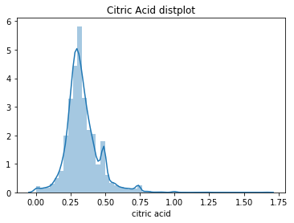

```python
sns.distplot(df['citric acid'])
plt.title("Citric Acid distplot")
plt.show()
```

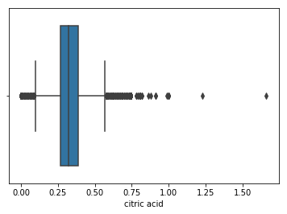

```python
sns.boxplot(df['citric acid'])
```

### Volatile acidity - countplot

from displot we can observe trends

1. we can observe skewness in this column.
2. These are continous.
3. In most of wines bottles we can observe volatile acidity of amount between 0.2% to 0.35%.

from boxplot we can observe trends

1. we can observe large amount of outliers.

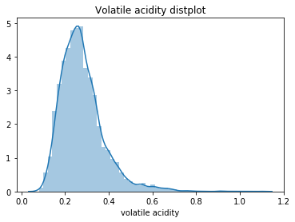

```python
sns.distplot(df['volatile acidity'])
plt.title("Volatile acidity distplot")
plt.show()
```

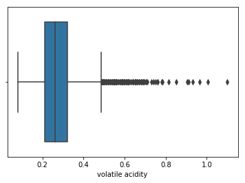

```python
sns.boxplot(df['volatile acidity'])
```

### fixed acidity - countplot

from displot we can observe trends

1. we can observe normal distribution of the column.
2. In most of wines bottles we can observe fixed acidity of amount between 6.2% to 7%.

from boxplot we can observe trends

1. we can observe large amount of outliers.

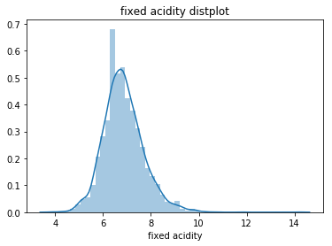

```python
sns.distplot(df['fixed acidity'])
plt.title("fixed acidity distplot")
plt.show()
```

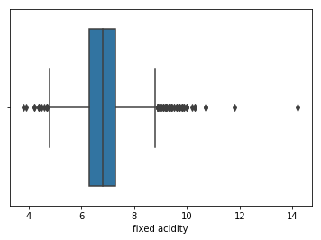

```python
sns.boxplot(df['fixed acidity'])
```

## Bivariate analysis

Bivariate analysis is the simultaneous analysis of two variables (attributes). It explores the concept of relationship between two variables, whether there exists an association and the strength of this association, or whether there are differences between two variables and the significance of these differences.

### What is/are the main feature(s) of interest in your dataset?

The quality of the white wine is what ulimately matters the most, all the other inputs combination is to produce a certain kind of test which is attributed to quality of the wine. Most wine quality is concentrated in the categories 5, 6, 7, small amount of white wine falls to categores 3, 4, 8 and 9 and not in the categories 1,2, and 10.

### .corr() method shows the corrleation between two variables.

```python
df.corr()
```

|  | fixed acidity | volatile acidity | citric acid | residual sugar | chlorides | free sulfur dioxide | total sulfur dioxide | density | pH | sulphates | alcohol | quality |
| --- | --- | --- | --- | --- | --- | --- | --- | --- | --- | --- | --- | --- |
| fixed acidity | 1.000000 | -0.022697 | 0.289181 | 0.089021 | 0.023086 | -0.049396 | 0.091070 | 0.265331 | -0.425858 | -0.017143 | -0.120881 | -0.113663 |
| volatile acidity | -0.022697 | 1.000000 | -0.149472 | 0.064286 | 0.070512 | -0.097012 | 0.089261 | 0.027114 | -0.031915 | -0.035728 | 0.067718 | -0.194723 |
| citric acid | 0.289181 | -0.149472 | 1.000000 | 0.094212 | 0.114364 | 0.094077 | 0.121131 | 0.149503 | -0.163748 | 0.062331 | -0.075729 | -0.009209 |
| residual sugar | 0.089021 | 0.064286 | 0.094212 | 1.000000 | 0.088685 | 0.299098 | 0.401439 | 0.838966 | -0.194133 | -0.026664 | -0.450631 | -0.097577 |
| chlorides | 0.023086 | 0.070512 | 0.114364 | 0.088685 | 1.000000 | 0.101392 | 0.198910 | 0.257211 | -0.090439 | 0.016763 | -0.360189 | -0.209934 |
| free sulfur dioxide | -0.049396 | -0.097012 | 0.094077 | 0.299098 | 0.101392 | 1.000000 | 0.615501 | 0.294210 | -0.000618 | 0.059217 | -0.250104 | 0.008158 |
| total sulfur dioxide | 0.091070 | 0.089261 | 0.121131 | 0.401439 | 0.198910 | 0.615501 | 1.000000 | 0.529881 | 0.002321 | 0.134562 | -0.448892 | -0.174737 |
| density | 0.265331 | 0.027114 | 0.149503 | 0.838966 | 0.257211 | 0.294210 | 0.529881 | 1.000000 | -0.093591 | 0.074493 | -0.780138 | -0.307123 |
| pH | -0.425858 | -0.031915 | -0.163748 | -0.194133 | -0.090439 | -0.000618 | 0.002321 | -0.093591 | 1.000000 | 0.155951 | 0.121432 | 0.099427 |
| sulphates | -0.017143 | -0.035728 | 0.062331 | -0.026664 | 0.016763 | 0.059217 | 0.134562 | 0.074493 | 0.155951 | 1.000000 | -0.017433 | 0.053678 |
| alcohol | -0.120881 | 0.067718 | -0.075729 | -0.450631 | -0.360189 | -0.250104 | -0.448892 | -0.780138 | 0.121432 | -0.017433 | 1.000000 | 0.435575 |
| quality | -0.113663 | -0.194723 | -0.009209 | -0.097577 | -0.209934 | 0.008158 | -0.174737 | -0.307123 | 0.099427 | 0.053678 | 0.435575 | 1.000000 |

### HeatMap

A heat map (or heatmap) is a graphical representation of data where the individual values contained in a matrix are represented as colors.This heatmap showing the correlation between all the variables present in the dataframe.

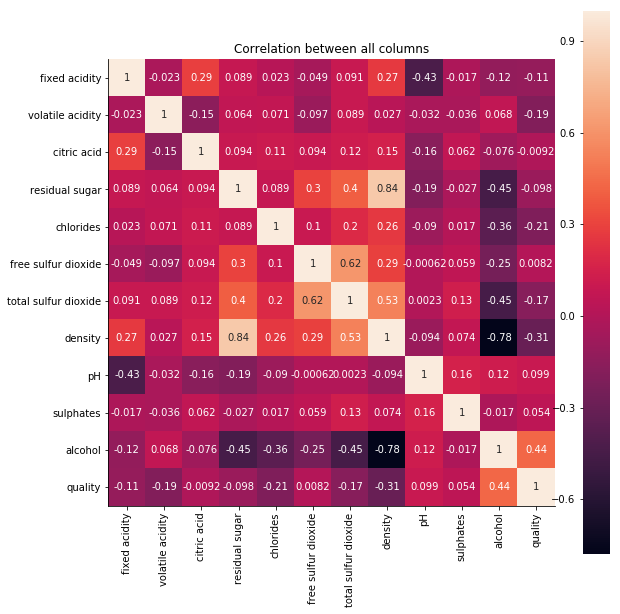

```python
plt.figure(figsize=(10,10))
sns.heatmap(df.corr(),annot=True,square=True)
sns.despine()
plt.title("Correlation between all columns")
plt.show()
```

### Alcohol v/s Quality

Here we plot regplot between these two variables(column),by this we find keys points for trend:

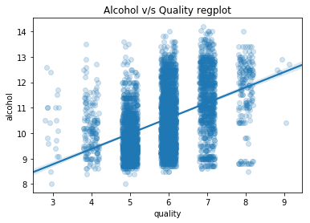

```python
sns.regplot(x='quality',y='alcohol',data=df,x_jitter=0.2,scatter_kws={'alpha':0.2})
plt.title("Alcohol v/s Quality regplot")
plt.show()
```

To see the alcohol contents corresponding to quality rating in precised manner have a look for boxplot for the same.

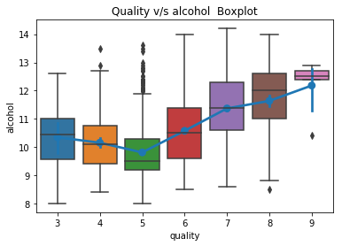

```python
# plt.figure(figsize=(8,7))
sns.boxplot(x='quality',y='alcohol',data=df)
sns.pointplot(x='quality',y='alcohol',data=df)
plt.title("Quality v/s alcohol  Boxplot")
plt.show()
sns.despine()
```

### Chlorides v/s Quality

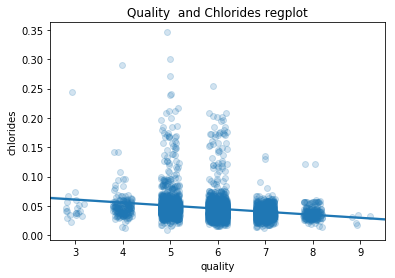

```python
sns.regplot(x='quality',y='chlorides',data=df,x_jitter=0.2,scatter_kws={'alpha':0.2})
plt.title("Quality  and Chlorides regplot")
plt.show()
```

### Residual sugar v/s Quality

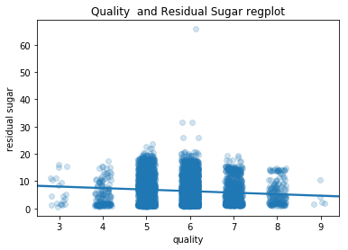

```python
sns.regplot(x='quality',y='residual sugar',data=df,x_jitter=0.2,scatter_kws={'alpha':0.2})
plt.title("Quality  and Residual Sugar regplot")
plt.show()
```

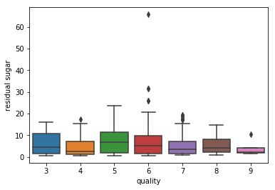

```python
sns.boxplot(x='quality',y='residual sugar',data=df)
```

### pH v/s Quality

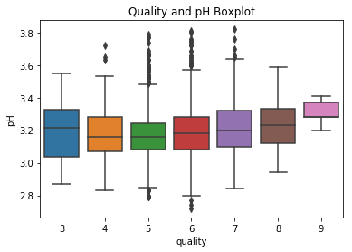

```python
sns.boxplot(x='quality',y='pH',data=df)
plt.title("Quality and pH Boxplot")
plt.show()
```

### Density v/s Quality

As we plot point plot for density and quality to get the trend.

1. As density increases, perceived quality decreases.
2. corelation cofficient b/w this is -0.31.

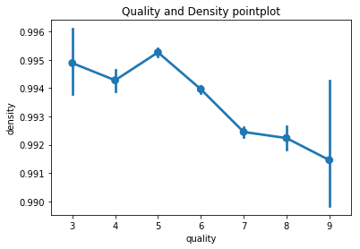

```python
sns.pointplot(x='quality',y='density',data=df)
plt.title("Quality and Density pointplot")
plt.show()
```

### Alcohol and Density

As we plot point plot for these two variables.

1. Alcohol and density are highly correlated to each other as correlation cofficient blw these two is -0.78.
2. As we can see alcohol affects both quality(increases) and density(decreases).
3. Because of the highly corelation b/w density and alcohol ,density affects opposite to quality.

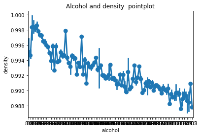

```python
sns.pointplot(x='alcohol',y='density',data=df)
plt.title("Alcohol and density  pointplot")
plt.show()
```

### Sulphates v/s Quality

Here we plot boxplot for sulphates and quality.

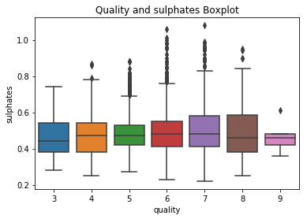

```python
sns.boxplot(x='quality',y='sulphates',data=df)
plt.title("Quality and sulphates Boxplot")
plt.show()
```

### Quality v/s fixed_acidity

here we plot box for these two columns.

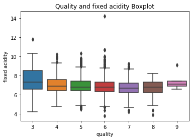

```python
sns.boxplot(x='quality',y='fixed acidity',data=df)
plt.title("Quality and fixed acidity Boxplot")
plt.show()
```

## Mutivariate Analysis

Multivariate Data Analysis refers to any statistical technique used to analyze data that arises from more than one variable. This essentially models reality where each situation, product, or decision involves more than a single variable.The techniques are especially valuable when working with correlated variables.

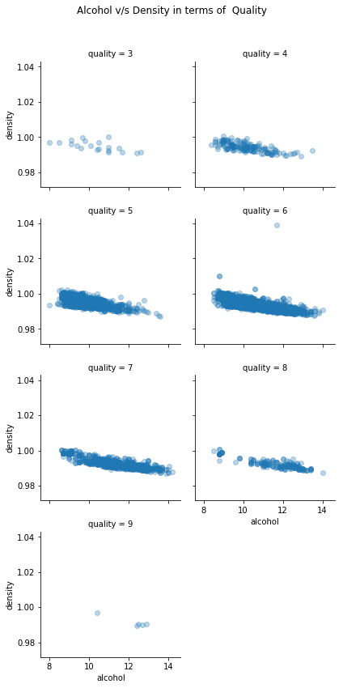

```python
grid=sns.FacetGrid(df,col='quality',col_wrap=2)
grid.map(plt.scatter,'alcohol','density',alpha=0.3)
plt.subplots_adjust(top=0.9)
grid.fig.suptitle('Alcohol v/s Density in terms of  Quality')
plt.show()
```

### Inferences from the above Alcohol v/s Density in terms of Quality plot.

This Facegrid highlights the differences in alcohol content and density in the top ranked wines and the lowest ranked wines. Generally, high quality wines have higher alcohol content and lower density. However, there are many observations which do not follow this general trend. Because alcohol and density are highly correlated,and also Alcohol and quality also highly correlated so we can't notice big difference.

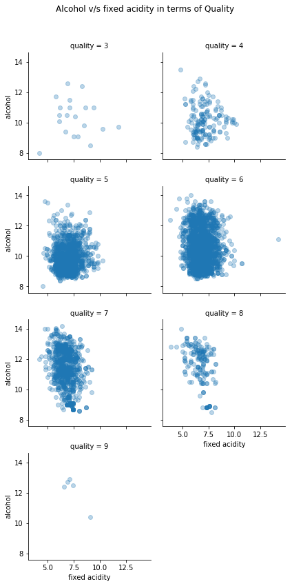

```python
grid=sns.FacetGrid(df,col='quality',col_wrap=2)
grid.map(plt.scatter,'fixed acidity','alcohol',alpha=0.3)
plt.subplots_adjust(top=0.9)
grid.fig.suptitle('Alcohol v/s fixed acidity in terms of Quality ')
plt.show()
```

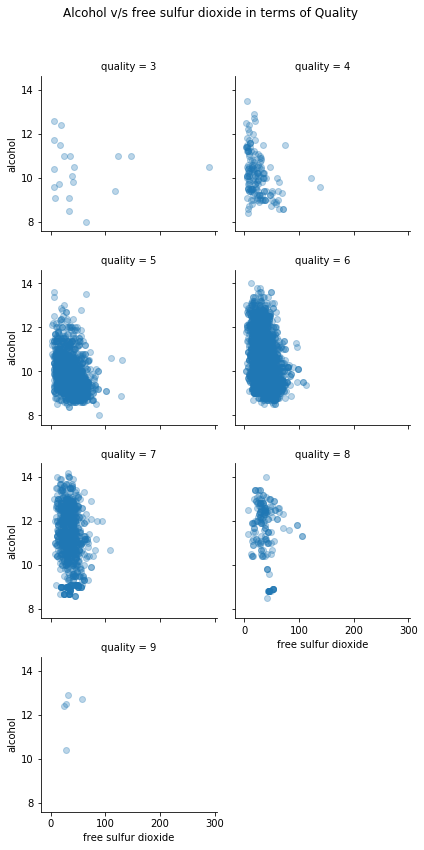

```python
grid=sns.FacetGrid(df,col='quality',col_wrap=2)
grid.map(plt.scatter,'free sulfur dioxide','alcohol',alpha=0.3)
plt.subplots_adjust(top=0.9)
grid.fig.suptitle('Alcohol v/s free sulfur dioxide in terms of Quality ')
plt.show()
```

### Inferences from the above Alcohol v/s free sulfur dioxide in terms of Quality plot

This Facetgrid demonstrates again that higher quality wines tend to have higher alcohol content. It explains less of the variation in the free sulfur dioxide variable between quality levels, except that higher quality wines have less varied free sulfur dioxide levels.

## Final plots and summary

### Plot One - Quality v/s Alcohol

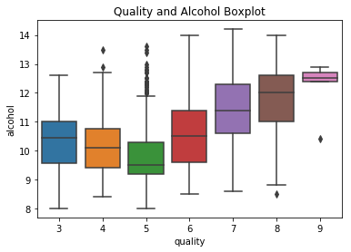

```python
sns.boxplot(x='quality',y='alcohol',data=df)
plt.title("Quality and Alcohol Boxplot")
plt.show()
```

### Description of one-:

The reason why I chose this graph as one of the final plots is because among all the features, alcohol level shows the strongest correlation (corr = 0.44) with wine quality rating.Alcohol level has a relatively small range from 8% to 14.2% . The majority of our wine ratings fall between 5-7. A better-rated wine has a higher alcohol level .

### Plot Two - Quality vs. Alcohol and Free Sulfur Dioxide

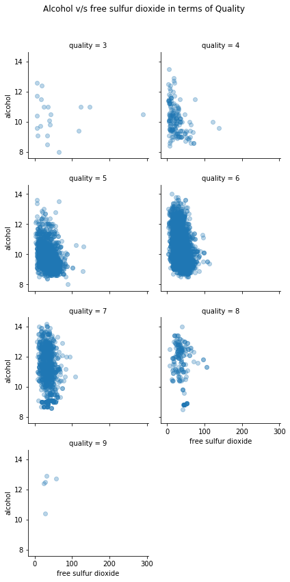

```python
grid=sns.FacetGrid(df,col='quality',col_wrap=2)
grid.map(plt.scatter,'free sulfur dioxide','alcohol',alpha=0.3)
plt.subplots_adjust(top=0.9)
grid.fig.suptitle('Alcohol v/s free sulfur dioxide in terms of Quality ')
plt.show()
```

### Plot Three - Quality v/s Alcohol and fixed_acidity

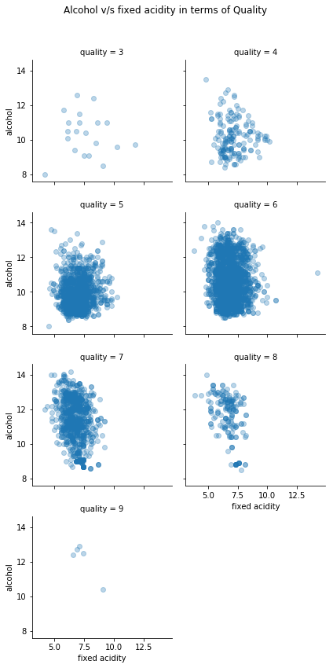

```python
grid=sns.FacetGrid(df,col='quality',col_wrap=2)
grid.map(plt.scatter,'fixed acidity','alcohol',alpha=0.3)
plt.subplots_adjust(top=0.9)
grid.fig.suptitle('Alcohol v/s fixed acidity in terms of Quality ')
plt.show()
```

## Summary

The White wine dataset contains almost 4898 observation and has 11 variables and one output(quality).First, I tried to understand each of the variable. I plotted the distribution on the way. My learnings after exploring the white wine dataset:

1. Alcohol is an important factor for the wine taste. At the same times, it interacts with other physcochemicals. For example, it can suppress the unpleasant odor and enhance acidity.
2. Free sulfur dioxide is really critical. At the level of 50m g/l, it becomes excessive and makes unpleasant smell noticeable that hurts the taste bud
3. Acidity is a fundamental property of wine, imparting sourness and resistance to microbial infection. Acidity is important for the Wine.